# Mock Interview Python Student Facing Questions

### Mock Interview Python Screening test

```python
import pandas as pd
import matplotlib as mpl
import matplotlib.pyplot as plt
dataframe = pd.read_csv("adult_census_data.csv")
```

```python
print(dataframe.columns)
```

```
Index(['39', ' State-gov', ' 77516', ' Bachelors', ' 13', ' Never-married',
       ' Adm-clerical', ' Not-in-family', ' White', ' Male', ' 2174', ' 0',
       ' 40', ' United-States', ' <=50K'],
      dtype='object')
```

**Q1. After importing the adult_census_data.csv file, please filter this to include only the following criteria:**

State-Gov

Bachelors

Never-Married

Adm-Clerical

Not-in-familiy

White

Male

United States

<=50K

**Feel free to any method to complete this tasks. However, we recommend you use either list filtering [], or .loc to complete this task.**

**Put your code below**

```python
columns_of_interest = [" State-gov", " Bachelors", " Never-married", " Adm-clerical", " Not-in-family", " White", " Male", " United-States", " <=50K"]
dataframe[columns_of_interest]
```

|  | State-gov | Bachelors | Never-married | Adm-clerical | Not-in-family | White | Male | United-States | <=50K |
| --- | --- | --- | --- | --- | --- | --- | --- | --- | --- |
| 0 | Self-emp-not-inc | Bachelors | Married-civ-spouse | Exec-managerial | Husband | White | Male | United-States | <=50K |
| 1 | Private | HS-grad | Divorced | Handlers-cleaners | Not-in-family | White | Male | United-States | <=50K |
| 2 | Private | 11th | Married-civ-spouse | Handlers-cleaners | Husband | Black | Male | United-States | <=50K |
| 3 | Private | Bachelors | Married-civ-spouse | Prof-specialty | Wife | Black | Female | Cuba | <=50K |
| 4 | Private | Masters | Married-civ-spouse | Exec-managerial | Wife | White | Female | United-States | <=50K |
| ... | ... | ... | ... | ... | ... | ... | ... | ... | ... |
| 32555 | Private | Assoc-acdm | Married-civ-spouse | Tech-support | Wife | White | Female | United-States | <=50K |
| 32556 | Private | HS-grad | Married-civ-spouse | Machine-op-inspct | Husband | White | Male | United-States | >50K |
| 32557 | Private | HS-grad | Widowed | Adm-clerical | Unmarried | White | Female | United-States | <=50K |
| 32558 | Private | HS-grad | Never-married | Adm-clerical | Own-child | White | Male | United-States | <=50K |
| 32559 | Self-emp-inc | HS-grad | Married-civ-spouse | Exec-managerial | Wife | White | Female | United-States | >50K |

32560 rows × 9 columns

**Currently, the dataframe you are using has the following column names:**

[' State-gov', ' Bachelors', ' Never-married', ' Adm-clerical', ' Not-in-family', ' White', ' Male', ' United-States', ' <=50K'] **Q2. Please re-name all the newly filtered columns in the pandas DataFrame to the following:**

Employment Type, Degree Status, Marriage-Status, Job-Role, Family-Role, Ethnicity, Gender, Country, Earnings

E.g. State-Gov becomes Employment Type, Bachelors becomes Degree Status, etc.

**Put your code below**

```python
dataframe.rename(columns={' State-gov': 'Employment Type', ' Bachelors': 'Degree Status', ' Never-married': 'Marriage-Status', ' Adm-clerical': 'Job-Role', ' Not-in-family': 'Family-Role', ' White': 'Ethnicity', ' Male': 'Gender', ' United-States': 'Country', ' <=50K': 'Earnings'}, inplace=True)

print(dataframe.columns)
```

```
Index(['39', 'Employment Type', ' 77516', 'Degree Status', ' 13',
       'Marriage-Status', 'Job-Role', 'Family-Role', 'Ethnicity', 'Gender',
       ' 2174', ' 0', ' 40', 'Country', 'Earnings'],
      dtype='object')
```

**Q3. The Job Role Columns holds the job information for each individual in this census snapshot. Using this column, create a Bar Chart that shows the count of 'Unique' Jobs per Job Group in the "Job-Role" Column in ascending order, as per the provided image below**

**Put your code below**

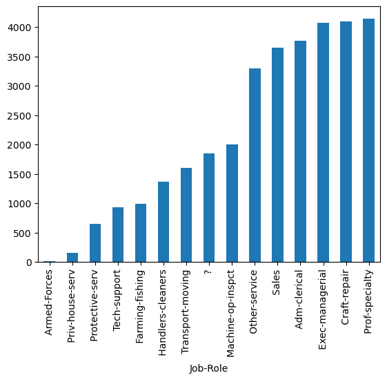

```python
job_count = dataframe['Job-Role'].value_counts(ascending=True)
job_count.plot(kind='bar')
plt.show()
```

**Q4. Please create two bar plots as per below that show:**

```
1) The number of individuals who have a High School Graduate Diploma AND earn <=50K in the United States
2) The number of individuals who have a High School Graduate Diploma AND earn >50K in the United States
```

Please note you will be looking specifically at the *Job Role* column

**Put Your Code Below**

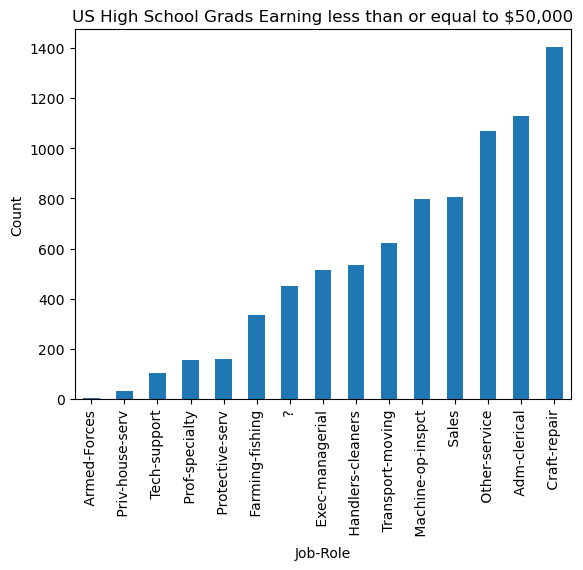

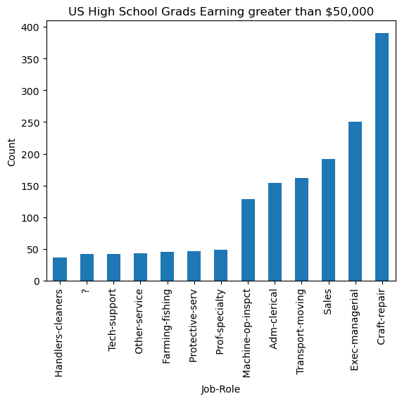

```python
hs_grad_50K = dataframe[(dataframe['Degree Status'] == ' HS-grad') & (dataframe['Earnings'] == ' <=50K') & (dataframe['Country'] == ' United-States')]
hs_grad_over50K = dataframe[(dataframe['Degree Status'] == ' HS-grad') & (dataframe['Earnings'] == ' >50K') & (dataframe['Country'] == ' United-States')]

hs_50K_count = hs_grad_50K['Job-Role'].value_counts().sort_values()
hs_50K_count.plot(kind='bar')
plt.ylabel('Count')
plt.title('US High School Grads Earning less than or equal to $50,000')
plt.show()


hs_over50K_count = hs_grad_over50K['Job-Role'].value_counts().sort_values()
hs_over50K_count.plot(kind='bar')
plt.ylabel('Count')
plt.title('US High School Grads Earning greater than $50,000')
plt.show()
```

## Challenge Question

**Q5. Which Job Role has the highest *proportion* of individuals who earn >50K?**

**Put your code below**

```python
hs_grad_over50K = dataframe[(dataframe['Degree Status'] == ' HS-grad') & (dataframe['Earnings'] == ' >50K') & (dataframe['Country'] == ' United-States')]
hs_over50K_count = hs_grad_over50K['Job-Role'].value_counts(normalize=True).sort_values(ascending=False)
print(hs_over50K_count)
```

```
Job-Role
Craft-repair         0.246368
Exec-managerial      0.157928
Sales                0.121289
Transport-moving     0.102337
Adm-clerical         0.097284
Machine-op-inspct    0.081491
Prof-specialty       0.030954
Protective-serv      0.029690
Farming-fishing      0.029059
Other-service        0.027164
?                    0.026532
Tech-support         0.026532
Handlers-cleaners    0.023373
Name: proportion, dtype: float64
```